# DESeq Analysis

James Lee

12/5/2020

```r
counts <- read.csv("airway_scaledcounts.csv", stringsAsFactors = FALSE, row.names=1)
metadata <-  read.csv("airway_metadata.csv", stringsAsFactors = FALSE)
```

```r
head(counts)
```

```
##                 SRR1039508 SRR1039509 SRR1039512 SRR1039513 SRR1039516
## ENSG00000000003        723        486        904        445       1170
## ENSG00000000005          0          0          0          0          0
## ENSG00000000419        467        523        616        371        582
## ENSG00000000457        347        258        364        237        318
## ENSG00000000460         96         81         73         66        118
## ENSG00000000938          0          0          1          0          2
##                 SRR1039517 SRR1039520 SRR1039521
## ENSG00000000003       1097        806        604
## ENSG00000000005          0          0          0
## ENSG00000000419        781        417        509
## ENSG00000000457        447        330        324
## ENSG00000000460         94        102         74
## ENSG00000000938          0          0          0
```

```r
head(metadata)
```

```
##           id     dex celltype     geo_id
## 1 SRR1039508 control   N61311 GSM1275862
## 2 SRR1039509 treated   N61311 GSM1275863
## 3 SRR1039512 control  N052611 GSM1275866
## 4 SRR1039513 treated  N052611 GSM1275867
## 5 SRR1039516 control  N080611 GSM1275870
## 6 SRR1039517 treated  N080611 GSM1275871
```

> Q1. How many genes are in this dataset?

There are 38694 genes in this dataset.

> Q2. How many ‘control’ cell lines do we have?

There are 4 control cell lines in this dataset.

### Basic way

```r
control <- metadata[metadata[,"dex"]=="control",]
control.counts <- counts[ ,control$id]
control.mean <- rowSums( control.counts )/4
head(control.mean)
```

```
## ENSG00000000003 ENSG00000000005 ENSG00000000419 ENSG00000000457 ENSG00000000460
##          900.75            0.00          520.50          339.75           97.25
## ENSG00000000938
##            0.75
```

### Alternative way using dplyr

```r
library(dplyr)
control <- metadata %>% filter(dex=="control")
control.counts <- counts %>% select(control$id)
control.mean <- rowSums(control.counts)/4
head(control.mean)
```

```
## ENSG00000000003 ENSG00000000005 ENSG00000000419 ENSG00000000457 ENSG00000000460
##          900.75            0.00          520.50          339.75           97.25
## ENSG00000000938
##            0.75
```

>Q3. How would you make the above code in either approach more robust?

Change rowSums to rowMeans and get rid of 4

> Q4. Follow the same procedure for the treated samples (i.e. calculate the mean per gene across drug treated samples and assign to a labeled vector called treated.mean)

```r
treated <- metadata[metadata[,"dex"]=="treated",]
treated.mean <- rowMeans( counts[ ,treated$id] )
names(treated.mean) <- counts$ensgene
meancounts <- data.frame(control.mean, treated.mean)
```

> Q5. Create a scatter plot showing the mean of the treated samples against the mean of the control samples. Your plot should look something like the following.

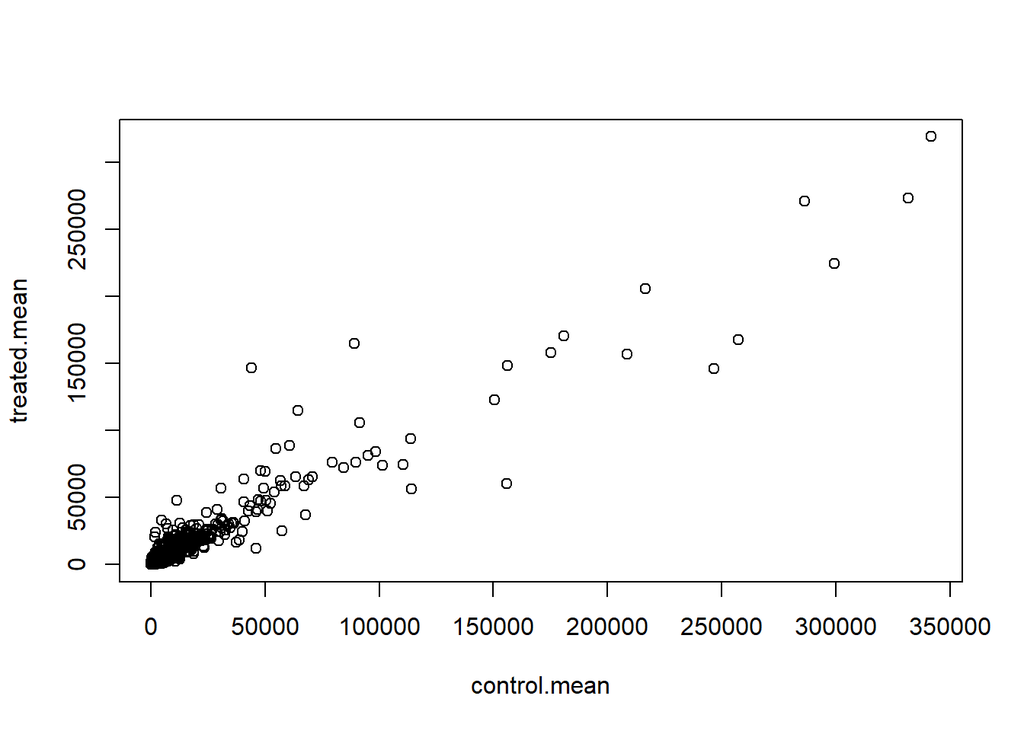

```r
count_plot <- plot(control.mean, treated.mean)
```

```r
count_plot
```

> Q6. Try plotting both axes on a log scale. What is the argument to plot() that allows you to do this?

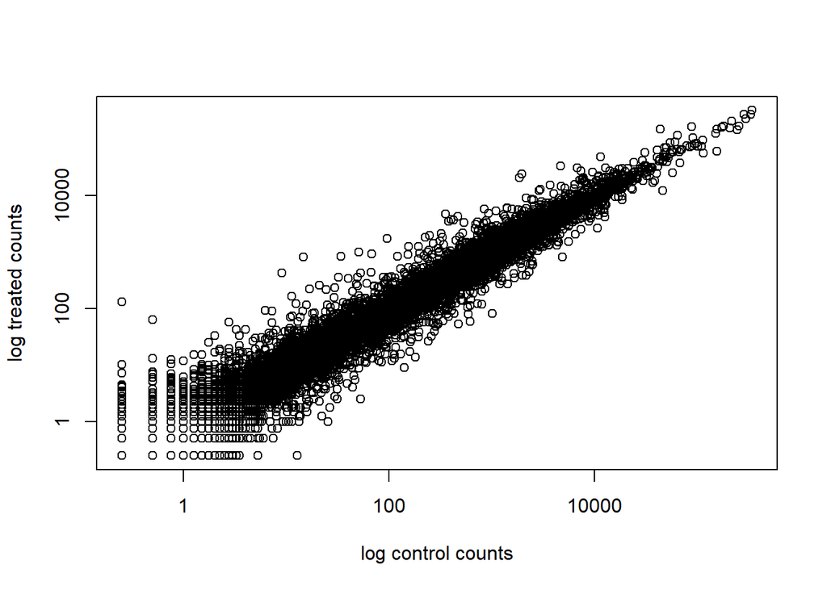

```r
count_plot_log <- plot(control.mean, treated.mean, log="xy",
                       xlab="log control counts",
                       ylab="log treated counts")
```

```r
count_plot_log
```

Calculate log2FC

```r
meancounts$log2fc <- log2(meancounts[,"treated.mean"]/meancounts[,"control.mean"])
head(meancounts)
```

```
##                 control.mean treated.mean      log2fc
## ENSG00000000003       900.75       658.00 -0.45303916
## ENSG00000000005         0.00         0.00         NaN
## ENSG00000000419       520.50       546.00  0.06900279
## ENSG00000000457       339.75       316.50 -0.10226805
## ENSG00000000460        97.25        78.75 -0.30441833
## ENSG00000000938         0.75         0.00        -Inf
```

```r
zero.vals <- which(meancounts[,1:2]==0, arr.ind=TRUE)

to.rm <- unique(zero.vals[,1])
mycounts <- meancounts[-to.rm,]
head(mycounts)
```

```
##                 control.mean treated.mean      log2fc
## ENSG00000000003       900.75       658.00 -0.45303916
## ENSG00000000419       520.50       546.00  0.06900279
## ENSG00000000457       339.75       316.50 -0.10226805
## ENSG00000000460        97.25        78.75 -0.30441833
## ENSG00000000971      5219.00      6687.50  0.35769358
## ENSG00000001036      2327.00      1785.75 -0.38194109
```

> Q7. What is the purpose of the arr.ind argument in the which() function call above? Why would we then take the first column of the output and need to call the unique() function?

It lets the which() function to return the row and column indices

A common threshold used for calling something differentially expressed is a log2(FoldChange) of greater than 2 or less than -2. Let’s filter the dataset both ways to see how many genes are up or down-regulated.

```r
up.ind <- mycounts$log2fc > 2
down.ind <- mycounts$log2fc < (-2)
```

> Q8. Using the up.ind vector above can you determine how many up regulated genes we have at the greater than 2 fc level?

Number of upregulated genes

```r
sum(up.ind)
```

```
## [1] 250
```

> Q9. Using the down.ind vector above can you determine how many down regulated genes we have at the greater than 2 fc level?

Number of downregulated genes

```r
sum(down.ind)
```

```
## [1] 367
```

> Q10. Do you trust these results? Why or why not?

No. Fold changes can be large without being statistically significant and we have not done anything to determine the significance.

## DESeq2 analysis

```r
dds <- DESeqDataSetFromMatrix(countData=counts,
                              colData=metadata,
                              design=~dex)
dds
```

```
## class: DESeqDataSet
## dim: 38694 8
## metadata(1): version
## assays(1): counts
## rownames(38694): ENSG00000000003 ENSG00000000005 ... ENSG00000283120
##   ENSG00000283123
## rowData names(0):
## colnames(8): SRR1039508 SRR1039509 ... SRR1039520 SRR1039521
## colData names(4): id dex celltype geo_id
```

```r
dds <- DESeq(dds)
```

Get results

```r
res <- results(dds)
res
```

```
## log2 fold change (MLE): dex treated vs control
## Wald test p-value: dex treated vs control
## DataFrame with 38694 rows and 6 columns
##                          baseMean     log2FoldChange             lfcSE
##                         <numeric>          <numeric>         <numeric>
## ENSG00000000003  747.194195359907 -0.350703020686589 0.168245681332903
## ENSG00000000005                 0                 NA                NA
## ENSG00000000419  520.134160051965  0.206107766417874 0.101059218008481
## ENSG00000000457  322.664843927049 0.0245269479387461 0.145145067649738
## ENSG00000000460   87.682625164828 -0.147142049222083 0.257007253995456
## ...                           ...                ...               ...
## ENSG00000283115                 0                 NA                NA
## ENSG00000283116                 0                 NA                NA
## ENSG00000283119                 0                 NA                NA
## ENSG00000283120 0.974916032393564 -0.668258460516795  1.69456285242458
## ENSG00000283123                 0                 NA                NA
##                               stat             pvalue              padj
##                          <numeric>          <numeric>         <numeric>
## ENSG00000000003  -2.08446967499072 0.0371174658436988 0.163034808643509
## ENSG00000000005                 NA                 NA                NA
## ENSG00000000419   2.03947517583776 0.0414026263009679  0.17603166488093
## ENSG00000000457  0.168982303952169  0.865810560624016 0.961694238404893
## ENSG00000000460 -0.572520996721302  0.566969065259218  0.81584858763974
## ...                            ...                ...               ...
## ENSG00000283115                 NA                 NA                NA
## ENSG00000283116                 NA                 NA                NA
## ENSG00000283119                 NA                 NA                NA
## ENSG00000283120 -0.394354484733718  0.693319342567684                NA
## ENSG00000283123                 NA                 NA                NA
```

```r
summary(res)
```

```
##
## out of 25258 with nonzero total read count
## adjusted p-value < 0.1
## LFC > 0 (up)       : 1563, 6.2%
## LFC < 0 (down)     : 1188, 4.7%
## outliers [1]       : 142, 0.56%
## low counts [2]     : 9971, 39%
## (mean count < 10)
## [1] see 'cooksCutoff' argument of ?results
## [2] see 'independentFiltering' argument of ?results
```

Customize the p value threshold at 5%

```r
res05 <- results(dds, alpha=0.05)
summary(res05)
```

```
##
## out of 25258 with nonzero total read count
## adjusted p-value < 0.05
## LFC > 0 (up)       : 1236, 4.9%
## LFC < 0 (down)     : 933, 3.7%
## outliers [1]       : 142, 0.56%
## low counts [2]     : 9033, 36%
## (mean count < 6)
## [1] see 'cooksCutoff' argument of ?results
## [2] see 'independentFiltering' argument of ?results
```

```r
columns(org.Hs.eg.db)
```

```
##  [1] "ACCNUM"       "ALIAS"        "ENSEMBL"      "ENSEMBLPROT"  "ENSEMBLTRANS"
##  [6] "ENTREZID"     "ENZYME"       "EVIDENCE"     "EVIDENCEALL"  "GENENAME"
## [11] "GO"           "GOALL"        "IPI"          "MAP"          "OMIM"
## [16] "ONTOLOGY"     "ONTOLOGYALL"  "PATH"         "PFAM"         "PMID"
## [21] "PROSITE"      "REFSEQ"       "SYMBOL"       "UCSCKG"       "UNIGENE"
## [26] "UNIPROT"
```

```r
res$symbol <- mapIds(org.Hs.eg.db,
                     keys=row.names(res), # Our genenames
                     keytype="ENSEMBL",        # The format of our genenames
                     column="SYMBOL",          # The new format we want to add
                     multiVals="first")
head(res)
```

```
## log2 fold change (MLE): dex treated vs control
## Wald test p-value: dex treated vs control
## DataFrame with 6 rows and 7 columns
##                          baseMean     log2FoldChange             lfcSE
##                         <numeric>          <numeric>         <numeric>
## ENSG00000000003  747.194195359907 -0.350703020686589 0.168245681332903
## ENSG00000000005                 0                 NA                NA
## ENSG00000000419  520.134160051965  0.206107766417874 0.101059218008481
## ENSG00000000457  322.664843927049 0.0245269479387461 0.145145067649738
## ENSG00000000460   87.682625164828 -0.147142049222083 0.257007253995456
## ENSG00000000938 0.319166568913118  -1.73228897394308  3.49360097648095
##                               stat             pvalue              padj
##                          <numeric>          <numeric>         <numeric>
## ENSG00000000003  -2.08446967499072 0.0371174658436988 0.163034808643509
## ENSG00000000005                 NA                 NA                NA
## ENSG00000000419   2.03947517583776 0.0414026263009679  0.17603166488093
## ENSG00000000457  0.168982303952169  0.865810560624016 0.961694238404893
## ENSG00000000460 -0.572520996721302  0.566969065259218  0.81584858763974
## ENSG00000000938 -0.495846258804286  0.620002884826012                NA
##                      symbol
##                 <character>
## ENSG00000000003      TSPAN6
## ENSG00000000005        TNMD
## ENSG00000000419        DPM1
## ENSG00000000457       SCYL3
## ENSG00000000460    C1orf112
## ENSG00000000938         FGR
```

> Q11. Run the mapIds() function two more times to add the Entrez ID and UniProt accession and GENENAME as new columns called res$entrez, res$uniprot and res$genename.

```r
res$entrez <- mapIds(org.Hs.eg.db,
                     keys=row.names(res), # Our genenames
                     keytype="ENSEMBL",        # The format of our genenames
                     column="ENTREZID",          # The new format we want to add
                     multiVals="first")
res$uniprot <- mapIds(org.Hs.eg.db,
                     keys=row.names(res), # Our genenames
                     keytype="ENSEMBL",        # The format of our genenames
                     column="UNIPROT",          # The new format we want to add
                     multiVals="first")
res$genename <- mapIds(org.Hs.eg.db,
                     keys=row.names(res), # Our genenames
                     keytype="ENSEMBL",        # The format of our genenames
                     column="GENENAME",          # The new format we want to add
                     multiVals="first")
head(res)
```

```
## log2 fold change (MLE): dex treated vs control
## Wald test p-value: dex treated vs control
## DataFrame with 6 rows and 10 columns
##                          baseMean     log2FoldChange             lfcSE
##                         <numeric>          <numeric>         <numeric>
## ENSG00000000003  747.194195359907 -0.350703020686589 0.168245681332903
## ENSG00000000005                 0                 NA                NA
## ENSG00000000419  520.134160051965  0.206107766417874 0.101059218008481
## ENSG00000000457  322.664843927049 0.0245269479387461 0.145145067649738
## ENSG00000000460   87.682625164828 -0.147142049222083 0.257007253995456
## ENSG00000000938 0.319166568913118  -1.73228897394308  3.49360097648095
##                               stat             pvalue              padj
##                          <numeric>          <numeric>         <numeric>
## ENSG00000000003  -2.08446967499072 0.0371174658436988 0.163034808643509
## ENSG00000000005                 NA                 NA                NA
## ENSG00000000419   2.03947517583776 0.0414026263009679  0.17603166488093
## ENSG00000000457  0.168982303952169  0.865810560624016 0.961694238404893
## ENSG00000000460 -0.572520996721302  0.566969065259218  0.81584858763974
## ENSG00000000938 -0.495846258804286  0.620002884826012                NA
##                      symbol      entrez     uniprot
##                 <character> <character> <character>
## ENSG00000000003      TSPAN6        7105  A0A024RCI0
## ENSG00000000005        TNMD       64102      Q9H2S6
## ENSG00000000419        DPM1        8813      O60762
## ENSG00000000457       SCYL3       57147      Q8IZE3
## ENSG00000000460    C1orf112       55732  A0A024R922
## ENSG00000000938         FGR        2268      P09769
##                                                                    genename
##                                                                 <character>
## ENSG00000000003                                               tetraspanin 6
## ENSG00000000005                                                 tenomodulin
## ENSG00000000419 dolichyl-phosphate mannosyltransferase subunit 1, catalytic
## ENSG00000000457                                    SCY1 like pseudokinase 3
## ENSG00000000460                         chromosome 1 open reading frame 112
## ENSG00000000938              FGR proto-oncogene, Src family tyrosine kinase
```

```r
ord <- order( res$padj )
#View(res[ord,])
head(res[ord,])
```

```
## log2 fold change (MLE): dex treated vs control
## Wald test p-value: dex treated vs control
## DataFrame with 6 rows and 10 columns
##                         baseMean   log2FoldChange              lfcSE
##                        <numeric>        <numeric>          <numeric>
## ENSG00000152583 954.770931565544 4.36835864527067  0.237126791796417
## ENSG00000179094 743.252688449073 2.86388865850473  0.175569314419446
## ENSG00000116584 2277.91345410747 -1.0347007724444 0.0650984360864208
## ENSG00000189221 2383.75370672631 3.34154402446202  0.212405785252044
## ENSG00000120129 3440.70375496308  2.9652108028191  0.203695128555861
## ENSG00000148175 13493.9203682606 1.42716828092125  0.100389041283296
##                              stat               pvalue                 padj
##                         <numeric>            <numeric>            <numeric>
## ENSG00000152583  18.4220374769844 8.74489804716936e-76  1.3244148092438e-71
## ENSG00000179094   16.312011401165 8.10783556895323e-60 6.13965848458983e-56
## ENSG00000116584 -15.8944029173111 6.92854594217284e-57 3.49776094314025e-53
## ENSG00000189221  15.7318880015292 9.14432590595713e-56 3.46227039614302e-52
## ENSG00000120129  14.5571021940563 5.26424315865897e-48  1.5945392527578e-44
## ENSG00000148175  14.2163752405385 7.25127847826521e-46 1.83034354255544e-42
##                      symbol      entrez     uniprot
##                 <character> <character> <character>
## ENSG00000152583     SPARCL1        8404  A0A024RDE1
## ENSG00000179094        PER1        5187      O15534
## ENSG00000116584     ARHGEF2        9181      Q92974
## ENSG00000189221        MAOA        4128      P21397
## ENSG00000120129       DUSP1        1843      B4DU40
## ENSG00000148175        STOM        2040      F8VSL7
##                                                     genename
##                                                  <character>
## ENSG00000152583                                 SPARC like 1
## ENSG00000179094                 period circadian regulator 1
## ENSG00000116584 Rho/Rac guanine nucleotide exchange factor 2
## ENSG00000189221                          monoamine oxidase A
## ENSG00000120129               dual specificity phosphatase 1
## ENSG00000148175                                     stomatin
```

```r
write.csv(res[ord,], "deseq_results.csv")
```

## Data Visualization

Volcano Plot

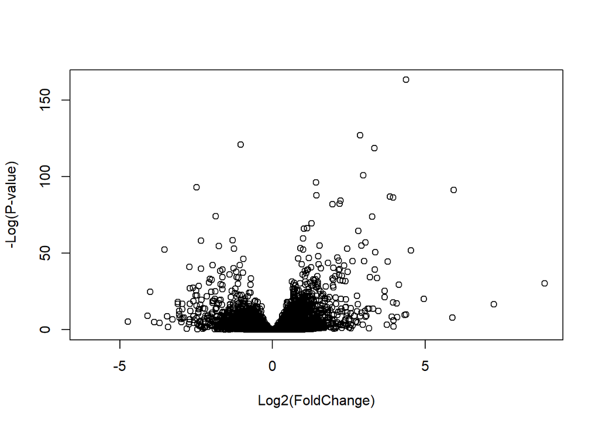

```r
plot( res$log2FoldChange,  -log(res$padj),
      xlab="Log2(FoldChange)",
      ylab="-Log(P-value)")
```

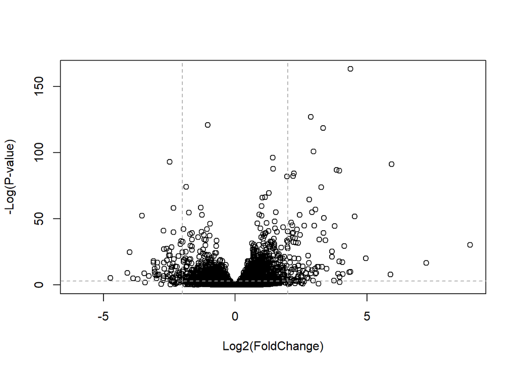

```r
plot( res$log2FoldChange,  -log(res$padj),
 ylab="-Log(P-value)", xlab="Log2(FoldChange)")

# Add some cut-off lines
abline(v=c(-2,2), col="darkgray", lty=2)
abline(h=-log(0.05), col="darkgray", lty=2)
```

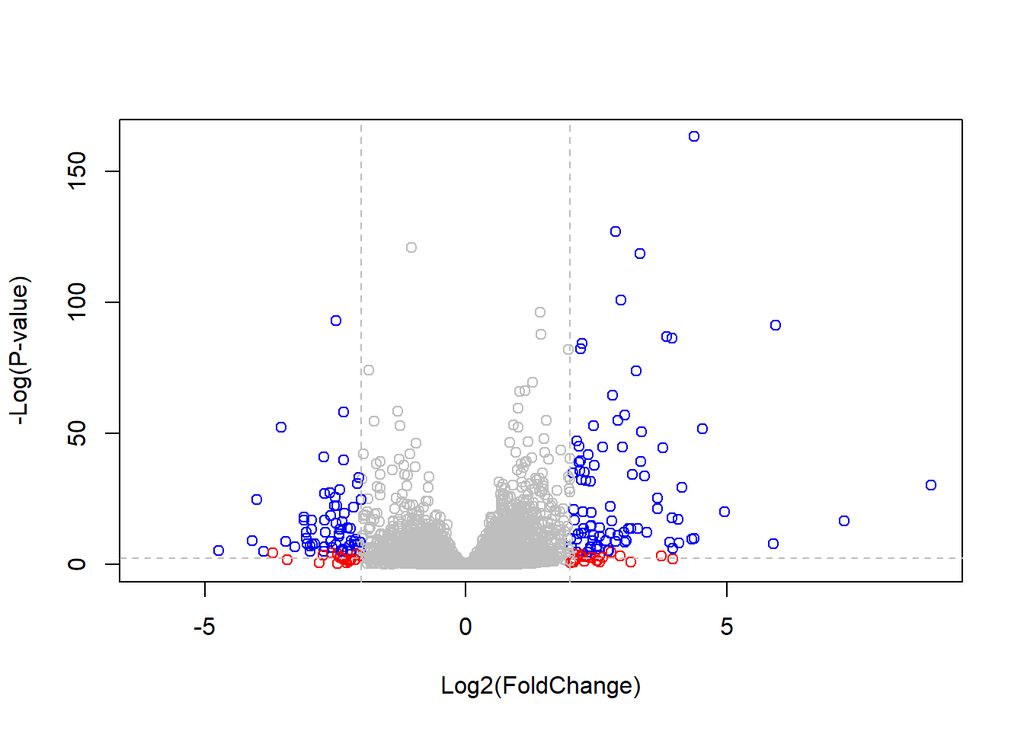

```r
# Setup our custom point color vector
mycols <- rep("gray", nrow(res))
mycols[ abs(res$log2FoldChange) > 2 ]  <- "red"

inds <- (res$padj < 0.01) & (abs(res$log2FoldChange) > 2 )
mycols[ inds ] <- "blue"

# Volcano plot with custom colors
plot( res$log2FoldChange,  -log(res$padj),
 col=mycols, ylab="-Log(P-value)", xlab="Log2(FoldChange)" )

# Cut-off lines
abline(v=c(-2,2), col="gray", lty=2)
abline(h=-log(0.1), col="gray", lty=2)
```

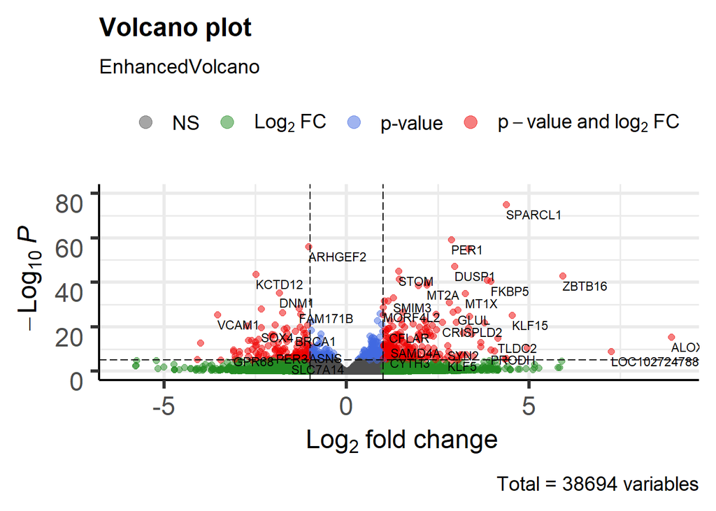

```r
x <- as.data.frame(res)

EnhancedVolcano(x,
    lab = x$symbol,
    x = 'log2FoldChange',
    y = 'pvalue')
```

## Pathway Analysis

```r
library(pathview)
library(gage)
library(gageData)

data(kegg.sets.hs)

# Examine the first 2 pathways in this kegg set for humans
head(kegg.sets.hs, 2)
```

```
## $`hsa00232 Caffeine metabolism`
## [1] "10"   "1544" "1548" "1549" "1553" "7498" "9"
##
## $`hsa00983 Drug metabolism - other enzymes`
##  [1] "10"     "1066"   "10720"  "10941"  "151531" "1548"   "1549"   "1551"
##  [9] "1553"   "1576"   "1577"   "1806"   "1807"   "1890"   "221223" "2990"
## [17] "3251"   "3614"   "3615"   "3704"   "51733"  "54490"  "54575"  "54576"
## [25] "54577"  "54578"  "54579"  "54600"  "54657"  "54658"  "54659"  "54963"
## [33] "574537" "64816"  "7083"   "7084"   "7172"   "7363"   "7364"   "7365"
## [41] "7366"   "7367"   "7371"   "7372"   "7378"   "7498"   "79799"  "83549"
## [49] "8824"   "8833"   "9"      "978"
```

```r
foldchanges = res$log2FoldChange
names(foldchanges) = res$entrez
head(foldchanges)
```

```
##        7105       64102        8813       57147       55732        2268
## -0.35070302          NA  0.20610777  0.02452695 -0.14714205 -1.73228897
```

```r
# Get the results
keggres = gage(foldchanges, gsets=kegg.sets.hs)
```

```r
attributes(keggres)
```

```
## $names
## [1] "greater" "less"    "stats"
```

```r
head(keggres$less, 3)
```

```
##                                       p.geomean stat.mean        p.val
## hsa05332 Graft-versus-host disease 0.0004250461 -3.473346 0.0004250461
## hsa04940 Type I diabetes mellitus  0.0017820293 -3.002352 0.0017820293
## hsa05310 Asthma                    0.0020045888 -3.009050 0.0020045888
##                                         q.val set.size         exp1
## hsa05332 Graft-versus-host disease 0.09053483       40 0.0004250461
## hsa04940 Type I diabetes mellitus  0.14232581       42 0.0017820293
## hsa05310 Asthma                    0.14232581       29 0.0020045888
```

```r
pathview(gene.data=foldchanges, pathway.id="hsa05310")
```

```
## Info: Working in directory C:/Users/james/Desktop/UCSD/BIMM143/week09/DESeq2
```

```
## Info: Writing image file hsa05310.pathview.png
```

```r
# A different PDF based output of the same data
pathview(gene.data=foldchanges, pathway.id="hsa05310", kegg.native=FALSE)
```

```
## Info: Working in directory C:/Users/james/Desktop/UCSD/BIMM143/week09/DESeq2
```

```
## Info: Writing image file hsa05310.pathview.pdf
```